# Simulation validation of counterfactual survival-time estimation

09 October 2026

# Introduction

This document describes a small simulation to assesses whether the process of estimating counterfactual survival times in the presence of multiple treatments and treatment switching (see supplementary data file 1), recovers unbiased calibration and discrimination metrics when evaluating the performance of a model predicting risk under the strategy of 'do nothing' for 10-year (aligned with the initial risk estimation component). The process for doing so is an extension of the work of Xu et al.,(Xu et al. 2021) and therefore requires some empirical testing.

This document is produced by a .Rmd file, which can be viewed to see the exact inputs for reproducibility of the simulation where necessary.

# Methods

**Overview**

- Observed survival times are simulated with time-varying statin, antihypertensive and smoking histories, to align with the applied analysis.
- Counterfactual survival times and model performance are estimated in the same manner as in the applied analysis.
- Latent oracle survival times are also simulated, where individuals do not deviate from treatment status at baseline (i.e. the treatment strategy we want to predict under, but do not observe in the real data), and performance is estimated with respect to these outcomes. We estimate bias as the difference of model performance between this, and performance estimated from the counterfactual survival times.
- We simulate data for two discrimination scenarios (target 0.6 and 0.8), and three calibration scenarios (model over predicts, under predicts, perfectly calibrated).
- For the estimation of counterfactual survival times, and estimation of model performance, we using the exact same R functions that were used the applied analysis.
- A prediction horizon of 10 years is used.

**Baseline data generation**

- Two cohorts are generated, one for the low-discrimination scenario (targeting C-index of 0.6) and one for the high-discrimination scenario (targeting C-index of 0.8). The cohort size is 1,000,000. With this large sample size, we can evaluate bias with one single simulation iteration, rather than taking a Monte Carlo approach.
- Three independent continuous predictors, `X1`, `X2` and `X3`, are generated from standard normal distributions.
- Baseline statin and antihypertensive statuses are generated as binary variables using logistic models that depend on the predictors.
- Baseline smoking is generated as a categorical variable with probabilities 0.55, 0.25 and 0.20 for non-smoker, ex-smoker and current smoker, respectively. Smoking is converted to the same two-dummy representation used in the applied analysis.

**Control of model discrimination and marginal risk**

- The relative coefficients for `X1`, `X2` and `X3` are fixed initially.
- A separate coefficient multiplier is found numerically for each discrimination scenario so that the C-index after administrative censoring at 10 years is approximately 0.60 or 0.80.
- A Weibull baseline cumulative hazard with shape 1.25 is used.
- A separate baseline-hazard scale is found numerically for each discrimination scenario so that the mean true 10-year risk under sustained baseline intervention status is approximately 0.10 in both scenarios.

**Longitudinal intervention histories**

- Follow-up is divided into intervals of 0.25 years.
- In each interval, individuals may start, stop or restart statins and antihypertensives at each interval. Transition probabilities depend on current treatment status and baseline predictors.
- Smoking may change from non-smoking to current smoking, from ex-smoking to current smoking, or from current smoking to ex-smoking.
- The resulting start-stop dataset is stored as `cohort_split_times`, using the same variable names and coding as the applied analysis.

**Outcome generation**

- One latent exponential event threshold is generated for each individual.
- The observed cumulative hazard is accumulated across intervals under the individual’s simulated time-varying intervention history. The log hazard ratios for statin use, antihypertensive use and changes to smoking status, are the same as those used in the applied analysis.
- The observed event time is the time at which cumulative hazard under the time-varying history crosses the latent threshold.
- The latent oracle event time under sustained baseline intervention status is generated using the same latent threshold but with all intervention deviations from baseline set to zero.
- Completely random censoring times are generated from an exponential distribution with a constant rate. Observed follow-up is the minimum of observed event time, censoring time and 10 years.

**Models and counterfactual outcome reconstruction**

- A start-stop Cox model is fitted to the observed outcomes in the longitudinal data.
- `X1`, `X2` and `X3` are fitted as prognostic predictors.
- The known statin, antihypertensive and smoking effects are included as time-varying offsets.
- The fitted centred baseline cumulative hazard is obtained using `survival::basehaz()`.
- Counterfactual survival times under the treatment strategy of sustaining baseline status are then estimated.
- This all matches the development of the initial risk estimation component in the applied analysis.

**Prediction scenarios**

- The perfectly calibrated model uses the true 10-year risk, estimated from the data simulator.
- The under-predicting model multiplies the true cumulative hazard by 0.70 before converting to a risk.
- The over-predicting model multiplies the true cumulative hazard by 1.30 before converting to a risk.
- Each calibration scenario is evaluated in both the low- and high-discrimination cohorts, giving six scenarios.

**Methods for comparison**

- Calibration and discrimination are estimated based on three different outcomes.
- 1. Latent counterfactual truth survival times: Latent oracle event times under sustained baseline status.
- 2. Estimated counterfactual survival times: Counterfactual times reconstructed from the observed outcomes, as is done in the main manuscript.
- 3. Observed outcomes under time-varying histories: Observed event and censoring times without counterfactual adjustment. These outcomes arise under intervention histories that depart from sustained baseline status, and therefore this should be biased.
- The first represents a ground truth, to which the latter two are compared. The primary comparison is the difference between model performance when validated using Latent counterfactual truth survival times, and Estimated counterfactual survival times.

**Performance metrics**

- Calibration curve using the approach of Austin et al.(Austin, Harrell, and Klaveren 2020)
- ICI is the mean absolute difference between estimated observed risk and predicted risk across individuals.
- E50 is the median absolute difference between estimated observed risk and predicted risk.
- E90 is the 90th percentile of the absolute differences.
- C-statistic is Harrell’s concordance statistic.

# Results and discussion

## Simulation diagnostics

Simulation diagnostics by discrimination scenario

| Targeted discrimination | Obtained discrimination | Mean true risk | Beta X1 | Beta X2 | Beta X3 |
| --- | --- | --- | --- | --- | --- |
| 0.6 | 0.601 | 0.1 | 0.249 | -0.204 | 0.162 |
| 0.8 | 0.801 | 0.1 | 0.877 | -0.725 | 0.560 |

## Calibration and discrimination

For every performance measure, the corresponding `_truth` column is performance calculated using the latent oracle event times for that scenario. Bias is calculated as the difference in model performance from the selected outcome dataset minus the corresponding latent oracle value. We see that there is minimal bias when the model is validated using the counterfactual outcomes calculated via the extension to the work of Xu et al.,(Xu et al. 2021) detailed in supplementary data file 1. This is evident both from the numerical performance metrics, and the calibration curve.

Interestingly, when estimating performance using the observed outcomes, calibration is clearly biased (as expected), but the amount of bias in the assessment of discrimination remains small.

Performance estimates and bias relative to latent counterfactual truth

|  | Discrimination | Calibration | Outcome source | Mean predicted risk | ICI | ICI truth | ICI bias | E50 | E50 truth | E50 bias | E90 | E90 truth | E90 bias | C-statistic | C-statistic truth | C-statistic bias |
| --- | --- | --- | --- | --- | --- | --- | --- | --- | --- | --- | --- | --- | --- | --- | --- | --- |
| 23 | high | overpredicts | Estimated counterfactual outcomes | 0.124 | 0.024 | 0.024 | **-0.000** | 0.016 | 0.016 | **-0.000** | 0.061 | 0.061 | **0.000** | 0.804 | 0.801 | **0.003** |
| 24 | high | overpredicts | Observed outcomes | 0.124 | 0.037 | 0.024 | **0.013** | 0.023 | 0.016 | **0.007** | 0.095 | 0.061 | **0.034** | 0.799 | 0.801 | **-0.002** |
| 15 | high | perfect | Estimated counterfactual outcomes | 0.100 | 0.000 | 0.000 | **0.000** | 0.000 | 0.000 | **0.000** | 0.001 | 0.001 | **0.000** | 0.804 | 0.801 | **0.003** |
| 16 | high | perfect | Observed outcomes | 0.100 | 0.013 | 0.000 | **0.012** | 0.007 | 0.000 | **0.007** | 0.034 | 0.001 | **0.033** | 0.799 | 0.801 | **-0.002** |
| 19 | high | underpredicts | Estimated counterfactual outcomes | 0.074 | 0.026 | 0.026 | **0.000** | 0.016 | 0.016 | **0.000** | 0.066 | 0.066 | **-0.000** | 0.804 | 0.801 | **0.003** |
| 20 | high | underpredicts | Observed outcomes | 0.074 | 0.013 | 0.026 | **-0.013** | 0.009 | 0.016 | **-0.007** | 0.032 | 0.066 | **-0.034** | 0.799 | 0.801 | **-0.002** |
| 11 | low | overpredicts | Estimated counterfactual outcomes | 0.128 | 0.028 | 0.028 | **0.000** | 0.026 | 0.026 | **0.000** | 0.040 | 0.040 | **0.000** | 0.601 | 0.601 | **0.000** |
| 12 | low | overpredicts | Observed outcomes | 0.128 | 0.041 | 0.028 | **0.013** | 0.038 | 0.026 | **0.012** | 0.061 | 0.040 | **0.021** | 0.596 | 0.601 | **-0.005** |
| 3 | low | perfect | Estimated counterfactual outcomes | 0.100 | 0.000 | 0.000 | **0.000** | 0.000 | 0.000 | **-0.000** | 0.001 | 0.000 | **0.000** | 0.601 | 0.601 | **0.000** |
| 4 | low | perfect | Observed outcomes | 0.100 | 0.013 | 0.000 | **0.013** | 0.012 | 0.000 | **0.011** | 0.021 | 0.000 | **0.021** | 0.596 | 0.601 | **-0.005** |
| 7 | low | underpredicts | Estimated counterfactual outcomes | 0.071 | 0.029 | 0.029 | **-0.000** | 0.028 | 0.028 | **-0.000** | 0.041 | 0.041 | **-0.000** | 0.601 | 0.601 | **0.000** |
| 8 | low | underpredicts | Observed outcomes | 0.071 | 0.016 | 0.029 | **-0.013** | 0.016 | 0.028 | **-0.012** | 0.020 | 0.041 | **-0.021** | 0.596 | 0.601 | **-0.005** |

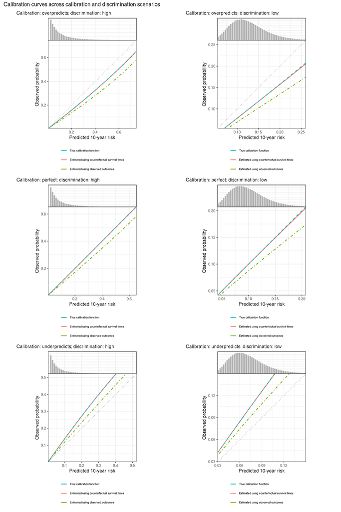

Austin, Peter C., Frank E. Harrell, and David van Klaveren. 2020. “Graphical Calibration Curves and the Integrated Calibration Index (ICI) for Survival Models.” Journal Article. *Statistics in Medicine* 39 (21): 2714–42. doi:10.1002/sim.8570.

Xu, Zhe, Matthew Arnold, David Stevens, Stephen Kaptoge, Lisa Pennells, Michael J. Sweeting, Jessica Barrett, Emanuele Di Angelantonio, and Angela M. Wood. 2021. “Prediction of Cardiovascular Disease Risk Accounting for Future Initiation of Statin Treatment.” Journal Article. *American Journal of Epidemiology* 190 (10): 2000–2014. doi:10.1093/aje/kwab031.